# College Student’s Food Perception

```r
# From your file menu (at the top of R-Studio) select:
# "Session -> Set working directory -> To source file location"
# Then play this chunk to get the data into R.
library(mosaic)
library(car)
library(DT)
library(pander)
library(readr)
library(knitr)
library(kableExtra)
library(formattable)
library(ggplot2)

food <- read_csv("../../Data/food.csv") #food.csv is in the Data folder...
```

## Background

The following experiment conducted consisted of a survey that went around a particular college campus asking students about their GPA and Weight as well as a variety of questions regarding food. There were questions asking about their comfort food, the likely hood of eating a specific cuisine, and if a health option or a junk food option came to mind when asking about a specific food.

In this study, we will be specifically examining the student’s weight as well as their perception of food to answer the following question:

*Does the perception of food among students at this college result in a change in their weight?*

Alternatively: If a student thinks healthier, do they have a lower weight? Or, if a student thinks unhealthy do they have a higher weight?

*For the data table of the following experiment and more information on the data table, click `Show Data Table`:*

### Show Data Table

The survey showed individuals two pictures to choose from when it came to associating foods with a specific words. The table below shows the different questions the survey asked in regards to word food association:

```r
questions <- c("Which one of these pictures do you associate the word 'breakfast'?",
               "Which picture do you associate with the word 'drink'?",
               "Which of these pictures you associate with word 'fries'?",
               "Which of the two pictures you associate with the word 'soup'?")

foodoptions <- c("Cereal /  Donut",
                 "1- Orange Juice / 2- Soda",
                 "1- McDonald's Fries / 2- Home Fries",
                 "1- Veggie Soup / 2- Creamy Soup")

collegestusurvey <- data.frame( Question = questions, Options = foodoptions, stringsAsFactors = FALSE)

kable(collegestusurvey, col.names = c("Questions", "Food Options"), caption ="Food Survey")
```

Food Survey

| Questions | Food Options |
| --- | --- |
| Which one of these pictures do you associate the word ‘breakfast’? | Cereal / Donut |
| Which picture do you associate with the word ‘drink’? | 1- Orange Juice / 2- Soda |
| Which of these pictures you associate with word ‘fries’? | 1- McDonald’s Fries / 2- Home Fries |
| Which of the two pictures you associate with the word ‘soup’? | 1- Veggie Soup / 2- Creamy Soup |

Thus, their answer was either expressed as a number or the specific word, one option being healthier than the other. If they chose the junk food option out of the two, they are rewarded a point that would then be counted for in their **Food Perception Score**. This would then result in scores ranging from 0-4, *0 being the healthy thinking and 4 being junk food thinking*. The **Food Perception Score** column is highlighted in green in the table to display each student’s score.

```r
Foood <- food %>%
  select(weight, breakfast, fries, drink, soup) %>%
  filter(!is.na(suppressWarnings(as.numeric(weight))) +
           is.na(drink)) %>%
  mutate(`Food Perception Score` = ifelse(breakfast == "Cereal", 0,
                               ifelse(breakfast == "Donut", 1, 0)) +
                        ifelse(fries == "1", 1, ifelse(fries == "2", 0, 0)) +
                        ifelse(drink == "orange juice", 0, ifelse(drink == "soda", 1, 0)) +
                        ifelse(soup == "1", 0, ifelse(soup == "2", 1, 0))) %>%
  mutate(weight = as.numeric(weight))

datatable(Foood, options=list(pageLength = 10)) %>%
  formatStyle('Food Perception Score', backgroundColor = 'lightgreen')
```

|  | weight | breakfast | fries | drink | soup | Food Perception Score |
| --- | --- | --- | --- | --- | --- | --- |
| 1 | 187 | Cereal | 2 | orange juice | 1 | 0 |
| 2 | 155 | Cereal | 1 | soda | 1 | 2 |
| 3 | 190 | Cereal | 1 | soda | 1 | 2 |
| 4 | 190 | Cereal | 1 | soda | 1 | 2 |
| 5 | 180 | Cereal | 1 | orange juice | 1 | 1 |
| 6 | 137 | Cereal | 1 | soda | 1 | 2 |
| 7 | 180 | Cereal | 1 | orange juice | 2 | 2 |
| 8 | 125 | Cereal | 1 | orange juice | 1 | 1 |
| 9 | 116 | Cereal | 1 | soda | 1 | 2 |
| 10 | 110 | Cereal | 1 | orange juice | 1 | 1 |

[output cut: 108 more lines]

## Hypothesis

To find the answers for our question above, we will be using a **Kruskal-Wallis Rank Sum Test**. Thus, we will use the following hypotheses:

$$H_0 : \text{All samples are from the
same distribution.}$$

$$H_a : \text{At least one sample's
distribution is stochastically different.}$$

In more depth, the null hypothesis states that the weights of college students, regardless of their food perception (healthy or unhealthy), **come from the same distribution at this specific college**. While the alternative hypothesis suggests that **at least one** type of food perception (healthy or unhealthy) results in a **different weight distribution among college students at this particular school**.

Additionally, our level of significance will be:

$$\alpha = 0.05$$

## Analysis

### Graphical/ Numerical Summaries

The following box plot helps to show us which distribution is the **highest** out of all the **Food Perception Scores**. The different shades of green show us the range in **Food Perception Scores**, *0 being the healthy thinking and 4 being junk food thinking*.

According the box plot, *college students with a Food Perception Score of 3 have the highest distribution in our sample*. Additionally, the five number summary of each box plot is given below the box plot.

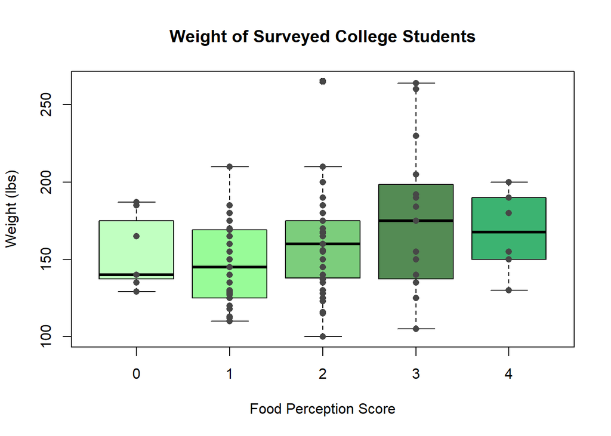

```r
boxplot(weight ~ `Food Perception Score`, data=Foood,
        col=c("darkseagreen1","palegreen","palegreen3","palegreen4","mediumseagreen"), xlab="Food Perception Score", main="Weight of Surveyed College Students", ylab="Weight (lbs)")
stripchart(weight ~ `Food Perception Score`, data=Foood, pch=16,vertical=TRUE, add=TRUE, col="gray28")
```

```r
Foodie <- favstats(weight ~ `Food Perception Score`, data = Foood)[,-10]

Foodie2 <- as.data.frame(Foodie)

kable(Foodie2)
```

| Food Perception Score | min | Q1 | median | Q3 | max | mean | sd | n |
| --- | --- | --- | --- | --- | --- | --- | --- | --- |
| 0 | 129 | 137.50 | 140.0 | 175.0 | 187 | 154.4286 | 24.31637 | 7 |
| 1 | 110 | 125.00 | 145.0 | 169.0 | 210 | 146.5946 | 25.90952 | 37 |
| 2 | 100 | 138.00 | 160.0 | 175.0 | 265 | 160.1887 | 28.97881 | 53 |
| 3 | 105 | 137.50 | 175.0 | 198.5 | 264 | 176.3333 | 48.17330 | 15 |
| 4 | 130 | 151.25 | 167.5 | 187.5 | 200 | 167.5000 | 26.78619 | 6 |

### Kruskal-Wallis Rank Sum Test

According to our Kruskal-Wallis test shown below, we have a p-value of **0.06521**.

```r
kruskal.test(weight ~ `Food Perception Score`, data=Foood) %>%
  pander()
```

Kruskal-Wallis rank sum test: `weight` by `Food Perception Score`

| Test statistic | df | P value |
| --- | --- | --- |
| 8.841 | 4 | 0.06521 |

$$p-value = 0.06521 > \alpha$$

Due to our high p-value, we are able to conclude that we have **insufficient** evidence to reject the null hypothesis.

## Interpretation

Even though the Kruskal-Wallis test shows us one thing, the visuals provided by the box plot tell us another. Student’s with a Food Perception Score of 3 had the **highest distribution** as well as the **highest median of 175** in our sample. Therefore, appearing to show us that there is at least one distribution that differs from the rest as stated in our alternative hypothesis.

However, with a p-value of **0.06521** slightly above our significance level (0.05), we have **insufficient evidence** to reject the null hypothesis for the surveyed school’s student population. This suggests that the way a student perceives food may not significantly affect the student’s weight distribution at this particular institution.

Sources:

- ChatGPT for helping me to figure out how to put in cool stylistic things such as the colored column in my data table
- Formatting Inspiration
  - Student Wages - Kruskal-Wallis Example
  - Pig Birth Weights - Kruskal-Wallis Example